# Bella Beat Analysis Project

Deborah Odeyemi

2024-06-30

## Bellabeat Overview

Bellabeat is a high-tech manufacturer of health-focused products for women. The Bellabeat app provides users with their health data via their smart devices, namely Leaf, Time, and Spring. Data collected from their users are related to their activity, sleep, stress, menstrual cycle, and mindfulness habits. The dataset used for this analysis comprises three main sources from Fitabase, which provides information on daily activity, sleep activity, and weight logs from April 2016 to May 2016.

## Business task

1. To reveal trends in how users interact with their smart devices.
2. To determine how these identified trends align with the needs and habits of Bellabeat’s target audience.
3. To Propose data-driven strategies to better market Bellabeat products.

### Data cleaning and removing of duplicte values

```r
daily_activity %>%
  clean_names() %>%
  distinct() %>%
  mutate(ActivityDate = mdy(activity_date)) %>%
  head()
```

```
##           id activity_date total_steps total_distance tracker_distance
## 1 1503960366     4/12/2016       13162           8.50             8.50
## 2 1503960366     4/13/2016       10735           6.97             6.97
## 3 1503960366     4/14/2016       10460           6.74             6.74
## 4 1503960366     4/15/2016        9762           6.28             6.28
## 5 1503960366     4/16/2016       12669           8.16             8.16
## 6 1503960366     4/17/2016        9705           6.48             6.48
##   logged_activities_distance very_active_distance moderately_active_distance
## 1                          0                 1.88                       0.55
## 2                          0                 1.57                       0.69
## 3                          0                 2.44                       0.40
## 4                          0                 2.14                       1.26
## 5                          0                 2.71                       0.41
## 6                          0                 3.19                       0.78
##   light_active_distance sedentary_active_distance very_active_minutes
```

[output cut: 20 more lines]

```r
sleep_day %>%
  clean_names() %>%
  distinct() %>%
  mutate(sleep_day = mdy_hms(sleep_day)) %>%
  head()
```

```
##           id  sleep_day total_sleep_records total_minutes_asleep
## 1 1503960366 2016-04-12                   1                  327
## 2 1503960366 2016-04-13                   2                  384
## 3 1503960366 2016-04-15                   1                  412
## 4 1503960366 2016-04-16                   2                  340
## 5 1503960366 2016-04-17                   1                  700
## 6 1503960366 2016-04-19                   1                  304
##   total_time_in_bed
## 1               346
## 2               407
## 3               442
## 4               367
## 5               712
## 6               320
```

```r
weight_info %>%
  clean_names() %>%
  distinct() %>%
  mutate(date = mdy_hms(date)) %>%
  head()
```

```
##           id                date weight_kg weight_pounds fat   bmi
## 1 1503960366 2016-05-02 23:59:59      52.6      115.9631  22 22.65
## 2 1503960366 2016-05-03 23:59:59      52.6      115.9631  NA 22.65
## 3 1927972279 2016-04-13 01:08:52     133.5      294.3171  NA 47.54
## 4 2873212765 2016-04-21 23:59:59      56.7      125.0021  NA 21.45
## 5 2873212765 2016-05-12 23:59:59      57.3      126.3249  NA 21.69
## 6 4319703577 2016-04-17 23:59:59      72.4      159.6147  25 27.45
##   is_manual_report       log_id
## 1             True 1.462234e+12
## 2             True 1.462320e+12
## 3            False 1.460510e+12
## 4             True 1.461283e+12
## 5             True 1.463098e+12
## 6             True 1.460938e+12
```

### Checking for number of missing values

```r
sum(is.na(daily_activity))
```

```
## [1] 0
```

```r
sum(is.na(sleep_day))
```

```
## [1] 0
```

```r
sum(is.na(weight_info))
```

```
## [1] 65
```

### Number of unique users in each data set

```r
distinct_daily_activity <- daily_activity %>%
  summarise(distinct_users = n_distinct(Id))
distinct_daily_activity
```

```
##   distinct_users
## 1             33
```

```r
distinct_sleep_day <- sleep_day %>%
  summarise(distinct_users = n_distinct(Id))
distinct_sleep_day
```

```
##   distinct_users
## 1             24
```

```r
distinct_weight_log <- weight_info %>%
  summarise(distinct_users = n_distinct(Id))
distinct_weight_log
```

```
##   distinct_users
## 1              8
```

### Relationship between sedentary minutes and total steps

```r
cor_steps_seden <- cor(daily_activity$TotalSteps, daily_activity$SedentaryMinutes)
```

### SedentaryMinutes Vs Total steps

[figure not shown]

```r
ggplot(data=daily_activity, aes(x = TotalSteps, y = SedentaryMinutes)) +
 geom_point( color = "blue") +
  geom_smooth(method = lm , color = "black")+
  labs(title = "Sedentary minutes Vs Total steps", x = "Sedentary Minutes", y = " Total Steps" ,
       subtitle = paste("Correlation Coefficient :", round(cor_steps_seden, 2)))
```

```r
cor_sleep_bed <- cor(sleep_day$TotalMinutesAsleep, sleep_day$TotalTimeInBed)
```

### Total time in bed Vs Total Minutes Asleep

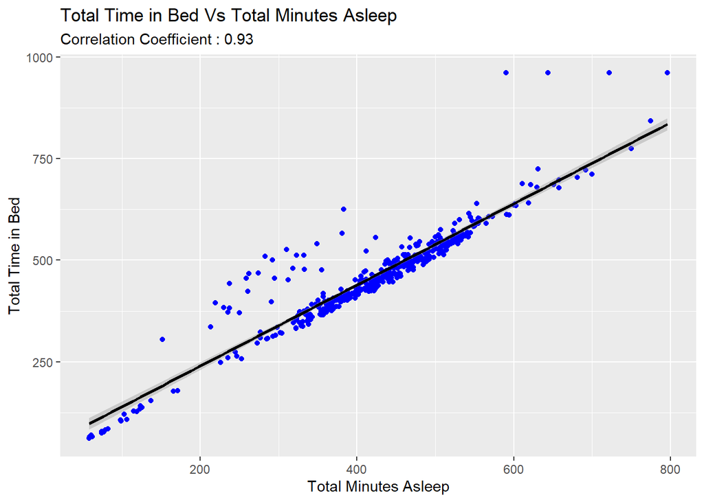

```r
ggplot(sleep_day, aes(x=TotalMinutesAsleep, y=TotalTimeInBed)) +
  geom_point( color = "blue" ) +
  geom_smooth(method = lm, color = "black") +
  labs(title = "Total Time in Bed Vs Total Minutes Asleep", x ="Total Minutes Asleep", y = "Total Time in Bed", subtitle = paste("Correlation Coefficient :", round(cor_sleep_bed, 2)))
```

### Set the order of the days of the week

```r
day_levels <- c("Sunday", "Monday", "Tuesday", "Wednesday", "Thursday", "Friday", "Saturday")
```

### Ensuring ActivityDate is in the proper date format

```r
daily_activity <- daily_activity %>%
  mutate(ActivityDate = mdy(ActivityDate))
```

### Aggregate of sedentary hours by day of the week

```r
weekly_sedentary <- daily_activity %>%
  mutate(day_of_week = factor(weekdays(ActivityDate), levels = day_levels)) %>%
  group_by(day_of_week) %>%
  summarise(avg_sedentary_hours = mean(SedentaryMinutes / 60, na.rm = TRUE))
```

### Sedentary hours Vs Day of the week

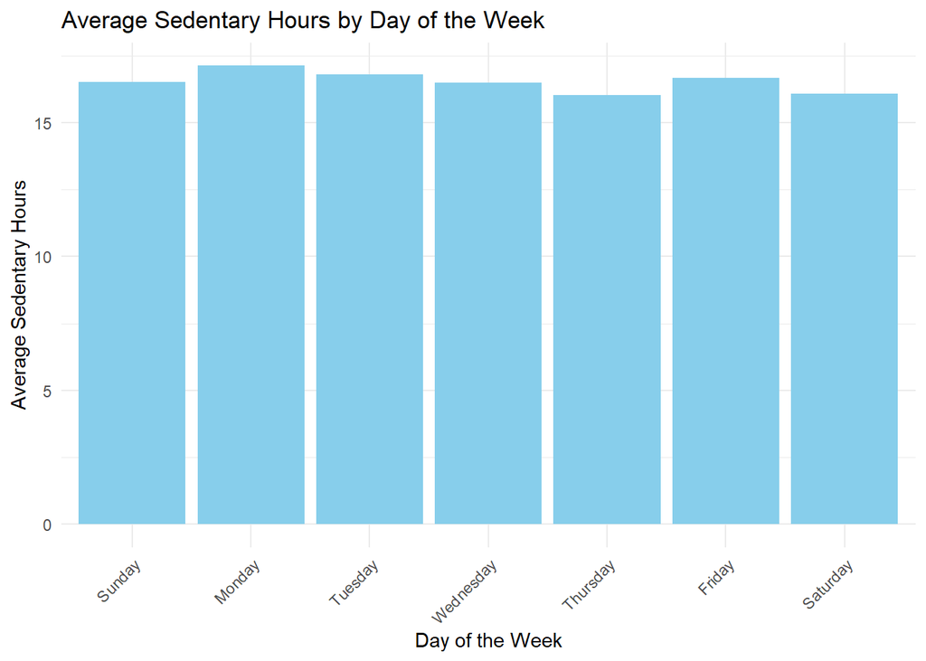

```r
ggplot(weekly_sedentary, aes(x = day_of_week, y = avg_sedentary_hours)) +
  geom_bar(stat = "identity", fill = "skyblue") +
  labs(title = "Average Sedentary Hours by Day of the Week",
       x = "Day of the Week", y = "Average Sedentary Hours") +
  theme_minimal() +
  theme(axis.text.x = element_text(angle = 45, hjust = 1))
```

### View of column names and structure

```r
colnames(sleep_day)
```

```
## [1] "Id"                 "SleepDay"           "TotalSleepRecords"
## [4] "TotalMinutesAsleep" "TotalTimeInBed"
```

```r
str(sleep_day)
```

```
## 'data.frame':    413 obs. of  5 variables:
##  $ Id                : num  1.5e+09 1.5e+09 1.5e+09 1.5e+09 1.5e+09 ...
##  $ SleepDay          : chr  "4/12/2016 12:00:00 AM" "4/13/2016 12:00:00 AM" "4/15/2016 12:00:00 AM" "4/16/2016 12:00:00 AM" ...
##  $ TotalSleepRecords : int  1 2 1 2 1 1 1 1 1 1 ...
##  $ TotalMinutesAsleep: int  327 384 412 340 700 304 360 325 361 430 ...
##  $ TotalTimeInBed    : int  346 407 442 367 712 320 377 364 384 449 ...
```

### Mutate SleepDay to POSIXct format

```r
sleep_day <- sleep_day %>%
  mutate(SleepDay = as.POSIXct(SleepDay, format = "%m/%d/%Y %I:%M:%S %p")) %>%
  mutate(TotalMinutesAsleep = as.numeric(TotalMinutesAsleep))
```

### Set the order of the days of the week

```r
day_levels <- c("Sunday", "Monday", "Tuesday", "Wednesday", "Thursday", "Friday", "Saturday")
```

### A weekly overview of sleep hours

```r
sleep_day <- sleep_day %>%
  mutate(day_of_week = factor(weekdays(SleepDay), levels = day_levels))

weekly_sleep <- sleep_day %>%
  group_by(day_of_week) %>%
  summarise(avg_sleep_hours = mean(TotalMinutesAsleep / 60, na.rm = TRUE))
```

### Average sleep hours Vs Day of the week

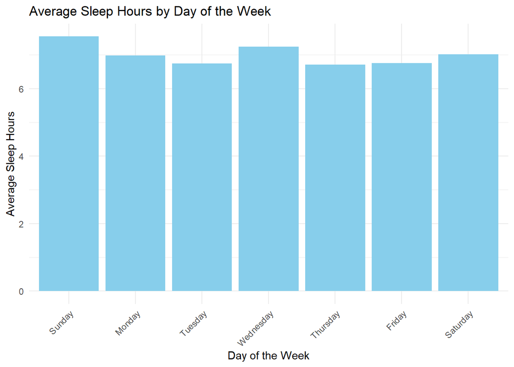

```r
ggplot(weekly_sleep, aes(x = day_of_week, y = avg_sleep_hours)) +
  geom_bar(stat = "identity", fill = "skyblue") +
  labs(title = "Average Sleep Hours by Day of the Week",
       x = "Day of the Week", y = "Average Sleep Hours") +
  theme_minimal() +
  theme(axis.text.x = element_text(angle = 45, hjust = 1))
```

### Merging of datasets by Id to check the level of correlation between variables

```r
sleep_day <-sleep_day %>%
  mutate(TotalHoursAsleep = round(TotalMinutesAsleep/60, 2))

combined_data <- daily_activity %>%
  full_join(sleep_day, by = "Id" )
combined_data <- combined_data %>%
  drop_na()

head(combined_data, 3)
```

```
##           Id ActivityDate TotalSteps TotalDistance TrackerDistance
## 1 1503960366   2016-04-12      13162           8.5             8.5
## 2 1503960366   2016-04-12      13162           8.5             8.5
## 3 1503960366   2016-04-12      13162           8.5             8.5
##   LoggedActivitiesDistance VeryActiveDistance ModeratelyActiveDistance
## 1                        0               1.88                     0.55
## 2                        0               1.88                     0.55
## 3                        0               1.88                     0.55
##   LightActiveDistance SedentaryActiveDistance VeryActiveMinutes
## 1                6.06                       0                25
## 2                6.06                       0                25
## 3                6.06                       0                25
##   FairlyActiveMinutes LightlyActiveMinutes SedentaryMinutes Calories   SleepDay
## 1                  13                  328              728     1985 2016-04-12
## 2                  13                  328              728     1985 2016-04-13
## 3                  13                  328              728     1985 2016-04-15
##   TotalSleepRecords TotalMinutesAsleep TotalTimeInBed day_of_week
## 1                 1                327            346     Tuesday
## 2                 2                384            407   Wednesday
## 3                 1                412            442      Friday
##   TotalHoursAsleep
## 1             5.45
## 2             6.40
## 3             6.87
```

### Summmary of daily steps

```r
summary_daily <- daily_activity %>%
  group_by(ActivityDate) %>%
  summarise(avg_steps = mean(TotalSteps, na.rm = TRUE),
            avg_calories = mean(Calories, na.rm = TRUE))
summary_daily
```

```
## # A tibble: 31 × 3
##    ActivityDate avg_steps avg_calories
##    <date>           <dbl>        <dbl>
##  1 2016-04-12       8237.        2391.
##  2 2016-04-13       7199.        2287.
##  3 2016-04-14       7744.        2356.
##  4 2016-04-15       7534.        2355.
##  5 2016-04-16       8679.        2393.
##  6 2016-04-17       6409.        2231.
##  7 2016-04-18       7897.        2333.
##  8 2016-04-19       8049.        2359.
##  9 2016-04-20       8163.        2395.
## 10 2016-04-21       8244.        2422.
## # ℹ 21 more rows
```

### Formating of ActivityDate as day-level

```r
summary_daily <- summary_daily %>%
    mutate(ActivityDate = as.Date(ActivityDate, format = "%m/%d/%Y"))
```

### Line chart showing average daily steps

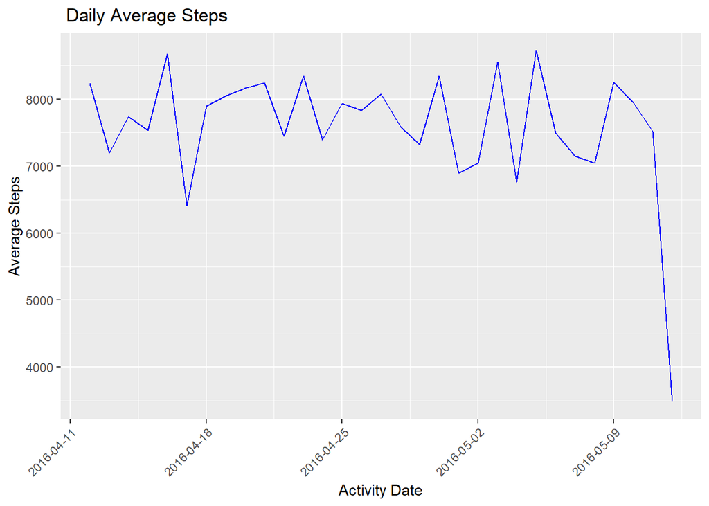

```r
 summary_daily %>%
    ggplot(aes(x = ActivityDate, y = avg_steps)) +
    geom_line(color = "blue") +
    scale_x_date(date_labels = "%Y-%m-%d") +
    labs(title = " Daily Average Steps", x = "Activity Date", y = "Average Steps") +
    theme(axis.text.x = element_text(angle = 45, hjust = 1))
```

### Relationship between Total steps and Calories burnt

```r
 correlationcoef_steps_calo <- cor(daily_activity$TotalSteps, daily_activity$Calories)
  correlationcoef_steps_calo
```

```
## [1] 0.5915681
```

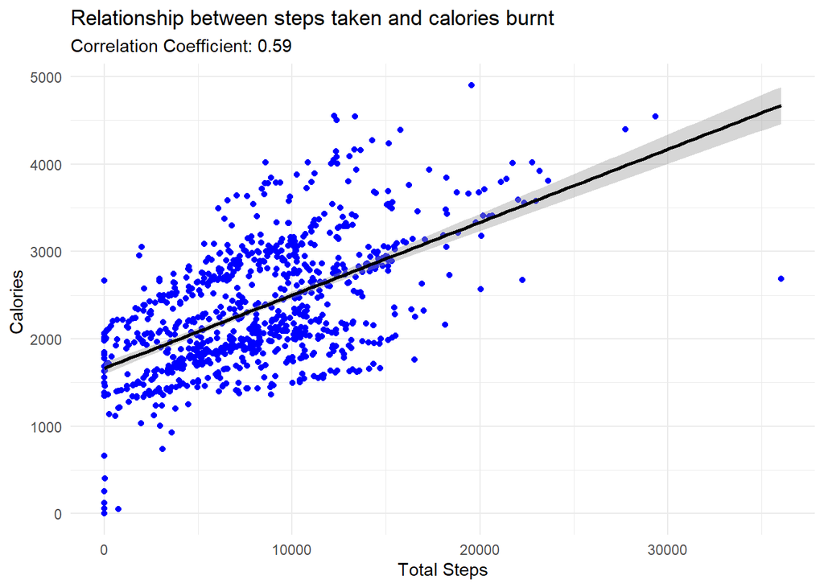

```r
  daily_activity %>%
    ggplot(aes(x=TotalSteps , y = Calories ))+
    geom_point(color = "blue")+
    geom_smooth(method = "lm" , color = "black")+
    labs(title = "Relationship between steps taken and calories burnt", x = "Total Steps", y = "Calories ",
    subtitle = paste("Correlation Coefficient:",round(correlationcoef_steps_calo, 2))) +
    theme_minimal()
```

### 2. Relationship between Total steps and Sleep hours

```r
correlationcoef_sleep_steps <- cor(combined_data$TotalSteps, combined_data$TotalHoursAsleep)
  correlationcoef_sleep_steps
```

```
## [1] -0.09850091
```

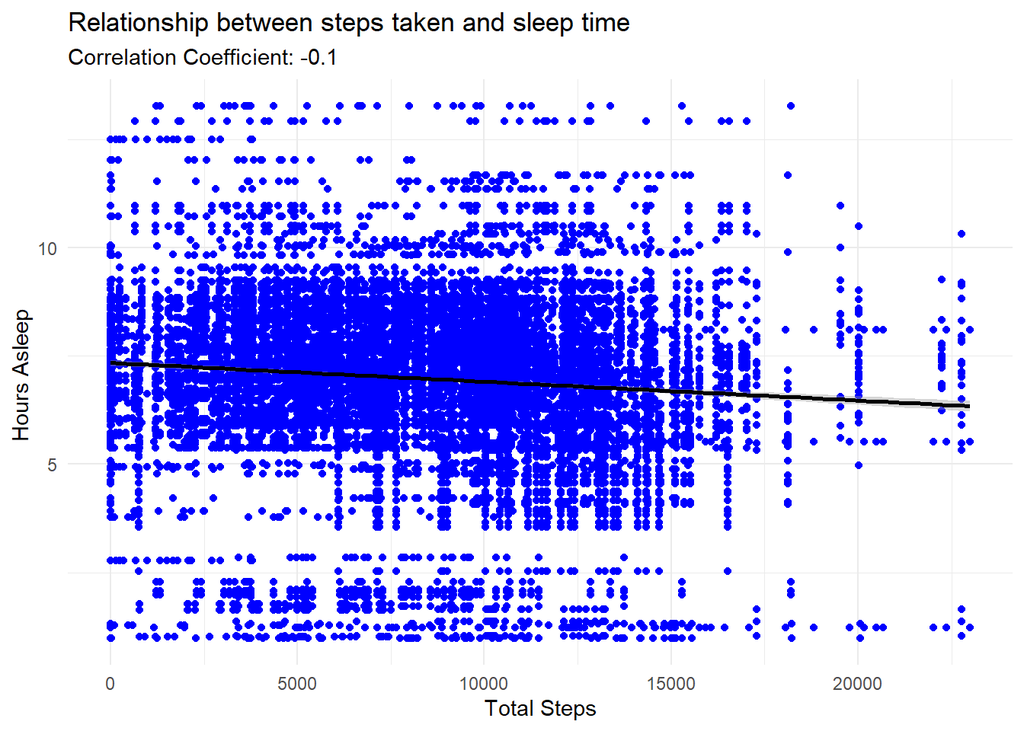

```r
  combined_data %>%
    ggplot(aes(x=TotalSteps , y = TotalHoursAsleep ))+
    geom_point(color = "blue")+
    geom_smooth(method = "lm" , color = "black")+
    labs(title = "Relationship between steps taken and sleep time", x = "Total Steps", y = "Hours Asleep ",
         subtitle = paste("Correlation Coefficient:",round(correlationcoef_sleep_steps, 2))) +
    theme_minimal()
```

## Recommendations

#### Increase Physical Activity:

Encourage users to aim for at least 10,000 steps per day to improve overall health.

#### Improve Sleep Quality:

Suggest bedtime routines and sleep hygiene practices to help users get better sleep.

#### Personalized Insights:

Provide personalized health insights and recommendations based on individual user data.

#### Encourage Weight Tracking:

Only 8 users have recorded their weight data. Encouraging more users to regularly log their weight can help in providing better health insights and tracking progress over time.

#### Promote Consistent Usage:

Due to inconsistencies in data logging due to irregular usage of the app and devices, we can implement features that motivate users to consistently log their data, such as streaks, badges, and rewards for continuous usage.

## Further Analysis Ideas:

Incorporate Age Group Insights: Conduct further analysis to understand usage patterns across different age groups. Customize marketing messages and product features to address the specific needs and preferences of various age demographics.